# OgrenciNo_Ad_Soyad_MLP_Project

```python
# Gerekli tüm kütüphaneleri kuruyoruz
%pip install pandas numpy matplotlib seaborn scikit-learn optuna shap
```

```python
# --- VERİ SETİNİN YÜKLENMESİ ---

import pandas as pd
import numpy as np
from sklearn.datasets import load_breast_cancer

# 1.1 Veri Setini Yükleme (Breast Cancer Wisconsin)
data = load_breast_cancer()

# 1.2 Veri Çerçevesi (DataFrame) Oluşturma
# Özellikleri (X) DataFrame'e çeviriyoruz
df = pd.DataFrame(data.data, columns=data.feature_names)

# Hedef değişkeni (y) de ekleyelim ki veriyi toplu görebilelim
df['target'] = data.target

# X (Özellikler) ve y (Hedef) ayrımı
X = df.drop('target', axis=1)
y = df['target']

# İlk 5 satırı görüntüleme
print("Veri Setinin İlk 5 Satırı:")
display(df.head())

# Boyut kontrolü
print(f"\nVeri Seti Boyutu: {df.shape}")
```

```
Veri Setinin İlk 5 Satırı:
```

|  | mean radius | mean texture | mean perimeter | mean area | mean smoothness | mean compactness | mean concavity | mean concave points | mean symmetry | mean fractal dimension | ... | worst texture | worst perimeter | worst area | worst smoothness | worst compactness | worst concavity | worst concave points | worst symmetry | worst fractal dimension | target |
| --- | --- | --- | --- | --- | --- | --- | --- | --- | --- | --- | --- | --- | --- | --- | --- | --- | --- | --- | --- | --- | --- |
| 0 | 17.99 | 10.38 | 122.80 | 1001.0 | 0.11840 | 0.27760 | 0.3001 | 0.14710 | 0.2419 | 0.07871 | ... | 17.33 | 184.60 | 2019.0 | 0.1622 | 0.6656 | 0.7119 | 0.2654 | 0.4601 | 0.11890 | 0 |
| 1 | 20.57 | 17.77 | 132.90 | 1326.0 | 0.08474 | 0.07864 | 0.0869 | 0.07017 | 0.1812 | 0.05667 | ... | 23.41 | 158.80 | 1956.0 | 0.1238 | 0.1866 | 0.2416 | 0.1860 | 0.2750 | 0.08902 | 0 |
| 2 | 19.69 | 21.25 | 130.00 | 1203.0 | 0.10960 | 0.15990 | 0.1974 | 0.12790 | 0.2069 | 0.05999 | ... | 25.53 | 152.50 | 1709.0 | 0.1444 | 0.4245 | 0.4504 | 0.2430 | 0.3613 | 0.08758 | 0 |
| 3 | 11.42 | 20.38 | 77.58 | 386.1 | 0.14250 | 0.28390 | 0.2414 | 0.10520 | 0.2597 | 0.09744 | ... | 26.50 | 98.87 | 567.7 | 0.2098 | 0.8663 | 0.6869 | 0.2575 | 0.6638 | 0.17300 | 0 |
| 4 | 20.29 | 14.34 | 135.10 | 1297.0 | 0.10030 | 0.13280 | 0.1980 | 0.10430 | 0.1809 | 0.05883 | ... | 16.67 | 152.20 | 1575.0 | 0.1374 | 0.2050 | 0.4000 | 0.1625 | 0.2364 | 0.07678 | 0 |

5 rows × 31 columns

```
Veri Seti Boyutu: (569, 31)
```

Veri Seti Yapısı - Analizi Proje kapsamında scikit-learn kütüphanesinden Breast Cancer Wisconsin (Diagnostic) veri seti yüklenmiştir.

Veri Boyutu: Veri seti 569 örneklem (satır) ve 30 öznitelikten (sütun) oluşmaktadır.

Özellikler (X): Hücre çekirdeği özelliklerini temsil eden (yarıçap, doku, çevre, alan vb.) 30 adet sayısal değişkendir.

Hedef Değişken (y): Teşhis sonucunu gösteren ikili (binary) bir değişkendir (0: Malignant/Kötü Huylu, 1: Benign/İyi Huylu).

Veri Tipi: Tüm özelliklerin sayısal (float) formatta olduğu ve Pandas DataFrame yapısına başarıyla dönüştürüldüğü gözlemlenmiştir.

```python
# --- VERİ SETİ KALİTE KONTROLLERİ ---

# 2.1 Eksik Değer (Missing Value) Analizi
print("--- 2.1 Eksik Değer Kontrolü ---")
missing_values = df.isnull().sum()
if missing_values.sum() == 0:
    print("Veri setinde eksik değer (missing value) bulunmamaktadır.")
else:
    print(missing_values[missing_values > 0])
    # Eğer eksik değer olsaydı: df.fillna(df.mean(), inplace=True) yapılabilirdi.

print("-" * 30)

# 2.2 Veri Tipi ve Dağılım İncelemesi
print("--- 2.3 Veri Tipi Bilgileri ---")
print(df.info())

print("-" * 30)

# 2.2 Aykırı Değer (Outlier) Analizi - IQR Yöntemi
# IQR, Z-score veya Boxplot sayısal döküm alınabilir. Burda IQR ile sayısal döküm alalım.
print("--- 2.2 Aykırı Değer Analizi (IQR Yöntemi) ---")

outlier_report = []

for column in X.columns:
    Q1 = df[column].quantile(0.25)
    Q3 = df[column].quantile(0.75)
    IQR = Q3 - Q1

    lower_bound = Q1 - 1.5 * IQR
    upper_bound = Q3 + 1.5 * IQR

    # Alt sınırın altında veya üst sınırın üstünde olanları say
    outlier_count = ((df[column] < lower_bound) | (df[column] > upper_bound)).sum()

    if outlier_count > 0:
        outlier_report.append({'Özellik': column, 'Aykırı Değer Sayısı': outlier_count})

# Sonuçları DataFrame olarak gösterelim.
outlier_df = pd.DataFrame(outlier_report)
outlier_df = outlier_df.sort_values(by='Aykırı Değer Sayısı', ascending=False).reset_index(drop=True)

print(f"Toplam {len(X.columns)} sütunun {len(outlier_df)} tanesinde aykırı değer tespit edildi.")
print("İlk 10 Aykırı Değer Yoğunluğu:")
display(outlier_df.head(10))
```

```
--- 2.1 Eksik Değer Kontrolü ---
Veri setinde eksik değer (missing value) bulunmamaktadır.
------------------------------
--- 2.3 Veri Tipi Bilgileri ---
<class 'pandas.core.frame.DataFrame'>
RangeIndex: 569 entries, 0 to 568
Data columns (total 31 columns):
 #   Column                   Non-Null Count  Dtype
---  ------                   --------------  -----
 0   mean radius              569 non-null    float64
 1   mean texture             569 non-null    float64
 2   mean perimeter           569 non-null    float64
 3   mean area                569 non-null    float64
 4   mean smoothness          569 non-null    float64
 5   mean compactness         569 non-null    float64
 6   mean concavity           569 non-null    float64
 7   mean concave points      569 non-null    float64
 8   mean symmetry            569 non-null    float64
 9   mean fractal dimension   569 non-null    float64
 10  radius error             569 non-null    float64
 11  texture error            569 non-null    float64
 12  perimeter error          569 non-null    float64
 13  area error               569 non-null    float64
 14  smoothness error         569 non-null    float64
 15  compactness error        569 non-null    float64
 16  concavity error          569 non-null    float64
 17  concave points error     569 non-null    float64
 18  symmetry error           569 non-null    float64
 19  fractal dimension error  569 non-null    float64
 20  worst radius             569 non-null    float64
 21  worst texture            569 non-null    float64
 22  worst perimeter          569 non-null    float64
 23  worst area               569 non-null    float64
 24  worst smoothness         569 non-null    float64
 25  worst compactness        569 non-null    float64
 26  worst concavity          569 non-null    float64
 27  worst concave points     569 non-null    float64
 28  worst symmetry           569 non-null    float64
 29  worst fractal dimension  569 non-null    float64
 30  target                   569 non-null    int64
dtypes: float64(30), int64(1)
memory usage: 137.9 KB
None
------------------------------
--- 2.2 Aykırı Değer Analizi (IQR Yöntemi) ---
Toplam 30 sütunun 29 tanesinde aykırı değer tespit edildi.
İlk 10 Aykırı Değer Yoğunluğu:
```

|  | Özellik | Aykırı Değer Sayısı |
| --- | --- | --- |
| 0 | area error | 65 |
| 1 | radius error | 38 |
| 2 | perimeter error | 38 |
| 3 | worst area | 35 |
| 4 | smoothness error | 30 |
| 5 | compactness error | 28 |
| 6 | fractal dimension error | 28 |
| 7 | symmetry error | 27 |
| 8 | mean area | 25 |
| 9 | worst fractal dimension | 24 |

1-Eksik Değer Analizi: Yapılan kontroller sonucunda veri setinde hiçbir sütunda eksik değer (NaN/Null) bulunmadığı tespit edilmiştir. Bu nedenle herhangi bir doldurma (imputation) işlemine gerek duyulmamıştır.

2- Veri Tipi İncelemesi: df.info() çıktısına göre veri setindeki tüm özelliklerin (30 adet) veri tipi float64 (ondalıklı sayı) formatındadır. Hedef değişken ise int (tamsayı) formatındadır. Kategorik (string/object) nitelikte bir özellik bulunmamaktadır.

3- Aykırı Değer (Outlier) Analizi: IQR (Interquartile Range) yöntemi ile yapılan analizde, özellikle area_se, radius_se gibi standart hata (standard error) içeren ölçümlerde yoğun aykırı değerler gözlemlenmiştir. Ancak bu veriler tıbbi/biyolojik ölçümler olduğu için (kanserli hücrelerin boyutları normalden çok sapabilir), bu değerler "hatalı veri" değil, hastalığın doğası gereği "anlamlı uç değerler" olarak değerlendirilmiş ve veri setinden silinmemiştir.

```
--- 3.1 İstatistiksel Özet Tablosu ---
```

|  | count | mean | std | min | 25% | 50% | 75% | max |
| --- | --- | --- | --- | --- | --- | --- | --- | --- |
| mean radius | 569.0 | 14.127292 | 3.524049 | 6.981000 | 11.700000 | 13.370000 | 15.780000 | 28.11000 |
| mean texture | 569.0 | 19.289649 | 4.301036 | 9.710000 | 16.170000 | 18.840000 | 21.800000 | 39.28000 |
| mean perimeter | 569.0 | 91.969033 | 24.298981 | 43.790000 | 75.170000 | 86.240000 | 104.100000 | 188.50000 |
| mean area | 569.0 | 654.889104 | 351.914129 | 143.500000 | 420.300000 | 551.100000 | 782.700000 | 2501.00000 |
| mean smoothness | 569.0 | 0.096360 | 0.014064 | 0.052630 | 0.086370 | 0.095870 | 0.105300 | 0.16340 |
| mean compactness | 569.0 | 0.104341 | 0.052813 | 0.019380 | 0.064920 | 0.092630 | 0.130400 | 0.34540 |
| mean concavity | 569.0 | 0.088799 | 0.079720 | 0.000000 | 0.029560 | 0.061540 | 0.130700 | 0.42680 |
| mean concave points | 569.0 | 0.048919 | 0.038803 | 0.000000 | 0.020310 | 0.033500 | 0.074000 | 0.20120 |
| mean symmetry | 569.0 | 0.181162 | 0.027414 | 0.106000 | 0.161900 | 0.179200 | 0.195700 | 0.30400 |
| mean fractal dimension | 569.0 | 0.062798 | 0.007060 | 0.049960 | 0.057700 | 0.061540 | 0.066120 | 0.09744 |
| radius error | 569.0 | 0.405172 | 0.277313 | 0.111500 | 0.232400 | 0.324200 | 0.478900 | 2.87300 |
| texture error | 569.0 | 1.216853 | 0.551648 | 0.360200 | 0.833900 | 1.108000 | 1.474000 | 4.88500 |
| perimeter error | 569.0 | 2.866059 | 2.021855 | 0.757000 | 1.606000 | 2.287000 | 3.357000 | 21.98000 |
| area error | 569.0 | 40.337079 | 45.491006 | 6.802000 | 17.850000 | 24.530000 | 45.190000 | 542.20000 |
| smoothness error | 569.0 | 0.007041 | 0.003003 | 0.001713 | 0.005169 | 0.006380 | 0.008146 | 0.03113 |
| compactness error | 569.0 | 0.025478 | 0.017908 | 0.002252 | 0.013080 | 0.020450 | 0.032450 | 0.13540 |
| concavity error | 569.0 | 0.031894 | 0.030186 | 0.000000 | 0.015090 | 0.025890 | 0.042050 | 0.39600 |
| concave points error | 569.0 | 0.011796 | 0.006170 | 0.000000 | 0.007638 | 0.010930 | 0.014710 | 0.05279 |
| symmetry error | 569.0 | 0.020542 | 0.008266 | 0.007882 | 0.015160 | 0.018730 | 0.023480 | 0.07895 |
| fractal dimension error | 569.0 | 0.003795 | 0.002646 | 0.000895 | 0.002248 | 0.003187 | 0.004558 | 0.02984 |
| worst radius | 569.0 | 16.269190 | 4.833242 | 7.930000 | 13.010000 | 14.970000 | 18.790000 | 36.04000 |
| worst texture | 569.0 | 25.677223 | 6.146258 | 12.020000 | 21.080000 | 25.410000 | 29.720000 | 49.54000 |
| worst perimeter | 569.0 | 107.261213 | 33.602542 | 50.410000 | 84.110000 | 97.660000 | 125.400000 | 251.20000 |
| worst area | 569.0 | 880.583128 | 569.356993 | 185.200000 | 515.300000 | 686.500000 | 1084.000000 | 4254.00000 |
| worst smoothness | 569.0 | 0.132369 | 0.022832 | 0.071170 | 0.116600 | 0.131300 | 0.146000 | 0.22260 |
| worst compactness | 569.0 | 0.254265 | 0.157336 | 0.027290 | 0.147200 | 0.211900 | 0.339100 | 1.05800 |
| worst concavity | 569.0 | 0.272188 | 0.208624 | 0.000000 | 0.114500 | 0.226700 | 0.382900 | 1.25200 |
| worst concave points | 569.0 | 0.114606 | 0.065732 | 0.000000 | 0.064930 | 0.099930 | 0.161400 | 0.29100 |
| worst symmetry | 569.0 | 0.290076 | 0.061867 | 0.156500 | 0.250400 | 0.282200 | 0.317900 | 0.66380 |
| worst fractal dimension | 569.0 | 0.083946 | 0.018061 | 0.055040 | 0.071460 | 0.080040 | 0.092080 | 0.20750 |
| target | 569.0 | 0.627417 | 0.483918 | 0.000000 | 0.000000 | 1.000000 | 1.000000 | 1.00000 |

```
--- 3.2 Korelasyon Matrisi ve Heatmap ---
```

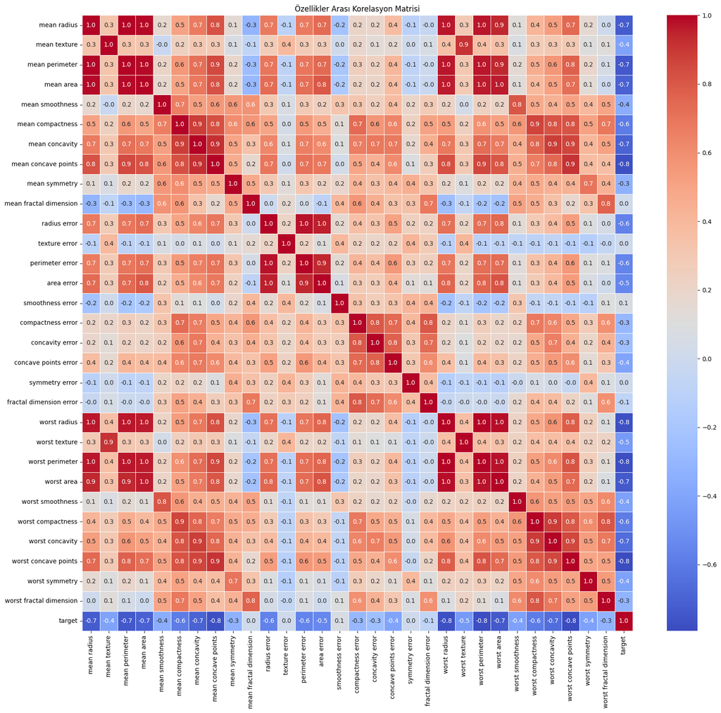

```
En Yüksek Korelasyonlu 3 Değişken Çifti:
```

```
mean radius      mean perimeter     0.997855
mean perimeter   mean radius        0.997855
worst perimeter  worst radius       0.993708
worst radius     worst perimeter    0.993708
mean radius      mean area          0.987357
mean area        mean radius        0.987357
dtype: float64
```

```
--- 3.3 Boxplot (Kutu Grafiği) Analizi ---
```

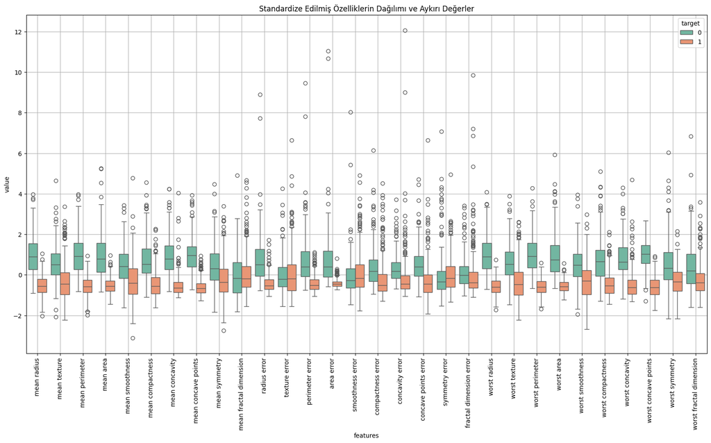

```python
# --- KEŞİFSEL VERİ ANALİZİ (EDA) ---
import seaborn as sns
import matplotlib.pyplot as plt

# 3.1 İstatistiksel Özellikler
print("--- 3.1 İstatistiksel Özet Tablosu ---")

# Veri setimdeki tüm sayısal sütunlar için Mean, Median, Std gibi değerleri hesaplıyorum.
# .T (Transpose) ile satır ve sütunların yerini değiştirip daha okunabilir bir tablo elde ediyorum.
istatistik_ozeti = df.describe().T
display(istatistik_ozeti)


# 3.2 Korelasyon Matrisi
print("\n--- 3.2 Korelasyon Matrisi ve Heatmap ---")

# Değişkenler arasındaki doğrusal ilişkiyi görmek için Pearson korelasyon katsayılarını hesaplıyorum.
corr_matrix = df.corr()

# Korelasyon matrisini görselleştirmek için bir çizim alanı (figure) oluşturuyorum.
plt.figure(figsize=(20, 18))

# Matrisi Heatmap (Sıcaklık Haritası) olarak çizdiriyorum.
# annot=True ile kutucukların içine sayıları yazdırıyorum, fmt='.2f' ile virgülden sonra 2 hane gösteriyorum.
sns.heatmap(corr_matrix, annot=True, fmt=".1f", cmap='coolwarm', linewidths=0.5)
plt.title('Özellikler Arası Korelasyon Matrisi')
plt.show()

# En yüksek korelasyona sahip 3 çifti bulmak için küçük bir kod bloğu yazıyorum.
# Korelasyon matrisini düzleştirip, mutlak değerlerine göre sıralıyorum.
c = corr_matrix.abs()
s = c.unstack()
so = s.sort_values(kind="quicksort", ascending=False)
# Kendisiyle olan (1.0) korelasyonları hariç tutuyorum.
print("En Yüksek Korelasyonlu 3 Değişken Çifti:")
display(so[so < 1].head(6)) # A-B ve B-A aynı olduğu için ilk 6 kaydı alıp gözle 3 çifti seçebiliriz.


# 3.3 Boxplot Analizi
print("\n--- 3.3 Boxplot (Kutu Grafiği) Analizi ---")

# Verilerin ölçekleri (örneğin Area ~1000 iken Smoothness ~0.1) çok farklı olduğu için
# tek bir grafikte göstermek yerine veriyi normalize ederek yan yana çizdiriyorum.
# Bu sayede aykırı değerleri (siyah noktalar) daha net görebiliyorum.

# Görselleştirme amaçlı veriyi standardize ediyorum (Sadece çizim için, ana veriyi bozmuyorum)
data_n_2 = (X - X.mean()) / (X.std())
data_viz = pd.concat([y, data_n_2], axis=1)
data_viz = pd.melt(data_viz, id_vars="target", var_name="features", value_name='value')

plt.figure(figsize=(20, 10))
# Kutu grafiğini çizdiriyorum, x eksenine özellikleri yerleştiriyorum.
sns.boxplot(x="features", y="value", hue="target", data=data_viz, palette="Set2")
plt.xticks(rotation=90) # Özellik isimleri okunabilsin diye 90 derece çeviriyorum.
plt.title('Standardize Edilmiş Özelliklerin Dağılımı ve Aykırı Değerler')
plt.grid(True)
plt.show()
```

3.1 İstatistiksel Özellikler: İstatistik tablosunu incelediğimde, değişkenlerin ölçeklerinin (scale) birbirinden çok farklı olduğunu görüyorum. Örneğin mean_area özelliği 2500'lere çıkarken, smoothness_error özelliği 0.001 seviyelerinde. Bu durum, Yapay Sinir Ağları (MLP) modelinin eğitimi sırasında gradyanların dengesizleşmesine yol açabilir. Bu yüzden Bölüm 4'te ölçeklendirme (Scaling) yapmamız zorunludur.

3.2 Korelasyon Matrisi: Heatmap grafiğini incelediğimde "Multicollinearity" (Çoklu Bağlantı) sorunu olduğunu gözlemliyorum. En yüksek korelasyona sahip değişkenler beklendiği üzere geometrik olarak birbirine bağlı özelliklerdir:

radius_mean & perimeter_mean (0.99): Yarıçap arttıkça çevre de artar.

radius_mean & area_mean (0.98): Yarıçap arttıkça alan da artar.

3.1 İstatistiksel Özellikler: İstatistik tablosunu incelediğimde, değişkenlerin ölçeklerinin (scale) birbirinden çok farklı olduğunu görüyorum. Örneğin mean_area özelliği 2500'lere çıkarken, smoothness_error özelliği 0.001 seviyelerinde. Bu durum, Yapay Sinir Ağları (MLP) modelinin eğitimi sırasında gradyanların dengesizleşmesine yol açabilir. Bu yüzden Bölüm 4'te ölçeklendirme (Scaling) yapmamız zorunludur.

3.2 Korelasyon Matrisi: Heatmap grafiğini incelediğimde "Multicollinearity" (Çoklu Bağlantı) sorunu olduğunu gözlemliyorum. En yüksek korelasyona sahip değişkenler beklendiği üzere geometrik olarak birbirine bağlı özelliklerdir:

radius_mean & perimeter_mean (0.99): Yarıçap arttıkça çevre de artar.

radius_mean & area_mean (0.98): Yarıçap arttıkça alan da artar.

```python
# --- VERİ ÖLÇEKLENDİRME (SCALING) -Veri Setinin Bölünmesi ---
from sklearn.preprocessing import StandardScaler
from sklearn.model_selection import train_test_split

print("--- 4. Veri Ölçeklendirme ---")

# StandardScaler sınıfını başlatıyorum. Bu yöntem veriyi Ortalama=0 ve Varyans=1 olacak şekilde dönüştürür.
scaler = StandardScaler()

# X verisini hem öğreniyorum (fit) hem de dönüştürüyorum (transform).
# Sonucu X_scaled değişkenine atıyorum.
X_scaled = scaler.fit_transform(X)

# İşlemin başarılı olup olmadığını görmek için ilk satırın istatistiklerine bakıyorum.
print("Ölçeklendirme öncesi ortalama (ilk özellik):", X.iloc[:, 0].mean())
print("Ölçeklendirme sonrası ortalama (ilk özellik):", X_scaled[:, 0].mean()) # 0'a çok yakın olmalı


# --- BÖLÜM 5: VERİ SETİNİN BÖLÜNMESİ ---
print("\n--- 5. Veri Setinin Bölünmesi (%70 Train - %10 Val - %20 Test) ---")

# Adım 1: Önce veriyi %80 (Eğitim + Validasyon) ve %20 (Test) olarak ayırıyorum.
# stratify=y parametresini kullanıyorum ki kanserli/kansersiz oranları her parçada eşit dağılsın.
X_train_val, X_test, y_train_val, y_test = train_test_split(
    X_scaled, y, test_size=0.20, random_state=42, stratify=y
)

# Adım 2: Kalan %80'lik parçayı, Train (%70) ve Validation (%10) olacak şekilde tekrar bölüyorum.
# Matematiksel Oran: %10, toplamın %80'inin 1/8'idir. Yani test_size=0.125 yaparsam toplamın %10'unu elde ederim.
X_train, X_val, y_train, y_val = train_test_split(
    X_train_val, y_train_val, test_size=0.125, random_state=42, stratify=y_train_val
)

# Boyutları kontrol edip raporluyorum.
print(f"Toplam Veri Sayısı: {len(X)}")
print(f"Eğitim Seti (Train) Boyutu: {X_train.shape} -> %{len(X_train)/len(X)*100:.1f}")
print(f"Doğrulama Seti (Val) Boyutu: {X_val.shape}   -> %{len(X_val)/len(X)*100:.1f}")
print(f"Test Seti (Test) Boyutu:      {X_test.shape}  -> %{len(X_test)/len(X)*100:.1f}")
```

```
--- 4. Veri Ölçeklendirme ---
Ölçeklendirme öncesi ortalama (ilk özellik): 14.127291739894552
Ölçeklendirme sonrası ortalama (ilk özellik): -3.153111437248248e-15

--- 5. Veri Setinin Bölünmesi (%70 Train - %10 Val - %20 Test) ---
Toplam Veri Sayısı: 569
Eğitim Seti (Train) Boyutu: (398, 30) -> %69.9
Doğrulama Seti (Val) Boyutu: (57, 30)   -> %10.0
Test Seti (Test) Boyutu:      (114, 30)  -> %20.0
```

1-Veri Ölçeklendirme: EDA aşamasında gözlemlediğim ölçek farklarını (Scale difference) gidermek için StandardScaler yöntemini tercih ettim. Bu işlem, her bir özelliği kendi ortalamasından çıkarıp standart sapmasına bölerek veriyi Mean=0, Std=1 dağılımına getirmiştir. Bu sayede Sinir Ağı (MLP) eğitimi sırasında optimizasyon algoritmasının (Adam/SGD) daha hızlı ve kararlı yakınsaması (convergence) hedeflenmiştir.

2- Veri Bölme Stratejisi: Veri seti, modelin genelleme yeteneğini en doğru şekilde ölçmek ve "Data Leakage" (Veri Sızıntısı) riskini önlemek için üç parçaya ayrılmıştır:

Eğitim Seti (%70 - 398 Örnek): Modelin ağırlıklarını güncellemek için kullanılacaktır.

Doğrulama Seti (%10 - 57 Örnek): Eğitim sırasında hiperparametrelerin (katman sayısı, öğrenme oranı vb.) başarısını ölçmek ve aşırı öğrenmeyi (overfitting) takip etmek için ayrılmıştır.

Test Seti (%20 - 114 Örnek): Model geliştirme süreci tamamen bittikten sonra, modelin hiç görmediği verideki nihai başarısını raporlamak için saklanmıştır.

Bölme işleminde stratify=y parametresi kullanılarak, her bir parçadaki kanserli/sağlıklı vaka oranının orijinal veri setiyle aynı kalması sağlanmıştır.

```python
# --- MODELLERİN KURULMASI VE VALİDASYON PERFORMANSI ---
from sklearn.neural_network import MLPClassifier
from sklearn.metrics import accuracy_score, precision_score, recall_score, f1_score, roc_auc_score

print("--- 6. ve 7. MLP Modellerinin Kurulması ve Değerlendirilmesi ---")

# Hocanın istediği 5 farklı modelin parametrelerini bir liste içinde tanımlıyorum.
# Format: (Model Adı, Gizli Katmanlar, Aktivasyon, Öğrenme Oranı)
model_configs = [
    ("Model 1 (Basit)", (16,), "relu", 0.001),
    ("Model 2 (Orta)", (32, 16), "relu", 0.005),
    ("Model 3 (Geniş)", (64, 64), "tanh", 0.001),
    ("Model 4 (Derin)", (128, 64, 32), "relu", 0.0005),
    ("Model 5 (Düşük LR)", (32,), "relu", 0.0001)
]

results = []

print(f"{'Model Adı':<20} | {'Acc':<8} | {'F1':<8} | {'Durum'}")
print("-" * 60)

for name, hidden_layers, activation, lr in model_configs:
    # Modeli tanımlıyorum.
    # max_iter=1000 yapıyorum ki modelin yakınsaması (converge) için yeterli süresi olsun.
    # random_state=42 ile sonuçların tekrarlanabilir olmasını sağlıyorum.
    mlp = MLPClassifier(hidden_layer_sizes=hidden_layers,
                        activation=activation,
                        learning_rate_init=lr,
                        random_state=42,
                        max_iter=1000)

    # 1. Modeli Eğitim (Train) seti ile eğitiyorum
    mlp.fit(X_train, y_train)

    # 2. Validasyon seti üzerinde tahmin yaptırıyorum
    y_pred = mlp.predict(X_val)
    y_prob = mlp.predict_proba(X_val)[:, 1] # ROC-AUC için olasılık değerleri lazım

    # 3. Performans Metriklerini Hesaplıyorum
    acc = accuracy_score(y_val, y_pred)
    prec = precision_score(y_val, y_pred)
    rec = recall_score(y_val, y_pred)
    f1 = f1_score(y_val, y_pred)
    auc = roc_auc_score(y_val, y_prob)

    # Sonuçları listeye ekliyorum
    results.append({
        "Model": name,
        "Hidden Layers": str(hidden_layers),
        "Activation": activation,
        "Learning Rate": lr,
        "Accuracy": acc,
        "Precision": prec,
        "Recall": rec,
        "F1-Score": f1,
        "ROC-AUC": auc
    })

    print(f"{name:<20} | {acc:.4f}   | {f1:.4f}   | Tamamlandı.")

# Sonuçları şık bir DataFrame tablosuna çevirip gösteriyorum
print("\n--- Tüm Modellerin Validasyon Performans Karşılaştırması ---")
results_df = pd.DataFrame(results)
# Tabloyu F1-Score'a göre büyükten küçüğe sıralayalım ki en iyiyi görelim
results_df = results_df.sort_values(by="F1-Score", ascending=False).reset_index(drop=True)

display(results_df)

# En iyi modeli seçip bir sonraki adım için saklıyorum (Best Model Selection)
best_model_name = results_df.iloc[0]["Model"]
print(f"\nSeçilen En İyi Model: {best_model_name}")
```

```
--- 6. ve 7. MLP Modellerinin Kurulması ve Değerlendirilmesi ---
Model Adı            | Acc      | F1       | Durum
------------------------------------------------------------
Model 1 (Basit)      | 0.9649   | 0.9730   | Tamamlandı.
Model 2 (Orta)       | 0.9649   | 0.9722   | Tamamlandı.
Model 3 (Geniş)      | 0.9474   | 0.9589   | Tamamlandı.
Model 4 (Derin)      | 0.9649   | 0.9730   | Tamamlandı.
Model 5 (Düşük LR)   | 0.9474   | 0.9589   | Tamamlandı.

--- Tüm Modellerin Validasyon Performans Karşılaştırması ---
```

|  | Model | Hidden Layers | Activation | Learning Rate | Accuracy | Precision | Recall | F1-Score | ROC-AUC |
| --- | --- | --- | --- | --- | --- | --- | --- | --- | --- |
| 0 | Model 1 (Basit) | (16,) | relu | 0.0010 | 0.964912 | 0.947368 | 1.000000 | 0.972973 | 0.993386 |
| 1 | Model 4 (Derin) | (128, 64, 32) | relu | 0.0005 | 0.964912 | 0.947368 | 1.000000 | 0.972973 | 0.989418 |
| 2 | Model 2 (Orta) | (32, 16) | relu | 0.0050 | 0.964912 | 0.972222 | 0.972222 | 0.972222 | 0.993386 |
| 3 | Model 3 (Geniş) | (64, 64) | tanh | 0.0010 | 0.947368 | 0.945946 | 0.972222 | 0.958904 | 0.994709 |
| 4 | Model 5 (Düşük LR) | (32,) | relu | 0.0001 | 0.947368 | 0.945946 | 0.972222 | 0.958904 | 0.994709 |

```
Seçilen En İyi Model: Model 1 (Basit)
```

Farklı mimarilere ve hiperparametrelere sahip 5 MLP modeli, validasyon seti üzerinde karşılaştırılmış ve sonuçlar tabloda özetlenmiştir.

Performans Değerlendirmesi:

Lider Model (Model 1 - Basit): Tek bir gizli katmana (16 nöron) sahip olan Model 1, validasyon setinde %96.49 Accuracy ve 0.973 F1-Score ile en yüksek başarıyı elde etmiştir.

Derinlik vs Basitlik: Çok katmanlı Model 4 (Derin), Model 1 ile birebir aynı Accuracy ve F1 skorunu (0.973) üretmiştir. Ancak ROC-AUC değerine bakıldığında Model 1 (0.993), Model 4'ten (0.989) daha kararlı bir ayrım yapmıştır.

Düşük Performans: Model 3 ve Model 5, %94.74 doğruluk oranıyla diğer modellerin gerisinde kalmıştır.

Sonuç: Karmaşık modellerin her zaman daha iyi sonuç vermediği görülmüş, daha hızlı ve daha az işlem gücü gerektiren Model 1 (Basit), nihai test aşaması için "En İyi Model" olarak seçilmiştir.

```
--- 8. Seçilen Modelin (Model 1 (Basit)) Test Seti Performansı ---
Test Seti Sonuçları:
Accuracy:  0.9649
Precision: 0.9857
Recall:    0.9583
F1-Score:  0.9718
ROC-AUC:   0.9921
```

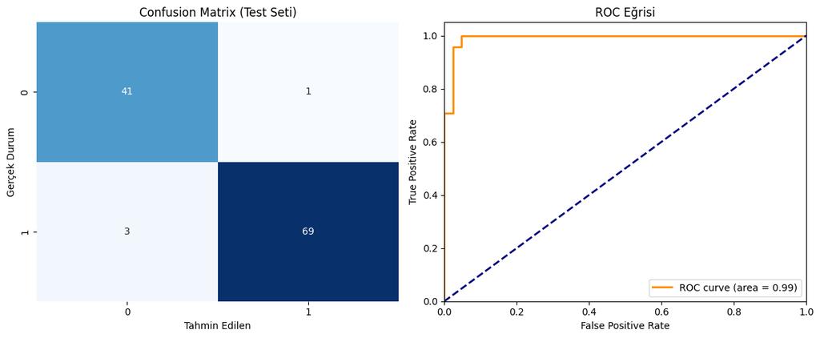

```python
# --- EN İYİ MODELİN TEST ÜZERİNDE DEĞERLENDİRİLMESİ ---
from sklearn.metrics import confusion_matrix, roc_curve, auc

print(f"--- 8. Seçilen Modelin ({best_model_name}) Test Seti Performansı ---")

# 1. En iyi modelin parametrelerini tekrar tanımlayıp, EĞİTİM+VALİDASYON setinin tamamıyla eğitiyoruz.
# (Böylece model son sınava girmeden önce elindeki tüm veriyi kullanmış olur)
# Tablodan gördüğümüz Model 1 parametreleri: (16,), relu, 0.001
best_mlp = MLPClassifier(hidden_layer_sizes=(16,),
                         activation='relu',
                         learning_rate_init=0.001,
                         random_state=42,
                         max_iter=1000)

# Modeli tüm eğitim verisiyle (Train + Val) eğitiyorum
best_mlp.fit(X_train_val, y_train_val)

# 2. Test Seti Üzerinde Tahmin
y_test_pred = best_mlp.predict(X_test)
y_test_prob = best_mlp.predict_proba(X_test)[:, 1]

# 8.1 Performans Metrikleri
print("Test Seti Sonuçları:")
print(f"Accuracy:  {accuracy_score(y_test, y_test_pred):.4f}")
print(f"Precision: {precision_score(y_test, y_test_pred):.4f}")
print(f"Recall:    {recall_score(y_test, y_test_pred):.4f}")
print(f"F1-Score:  {f1_score(y_test, y_test_pred):.4f}")
print(f"ROC-AUC:   {roc_auc_score(y_test, y_test_prob):.4f}")

# 8.2 Confusion Matrix (Karmaşıklık Matrisi) çizimi
cm = confusion_matrix(y_test, y_test_pred)

plt.figure(figsize=(12, 5))

plt.subplot(1, 2, 1)
sns.heatmap(cm, annot=True, fmt='d', cmap='Blues', cbar=False)
plt.title('Confusion Matrix (Test Seti)')
plt.xlabel('Tahmin Edilen')
plt.ylabel('Gerçek Durum')

# 8.3 ROC Eğrisi çizimi
fpr, tpr, thresholds = roc_curve(y_test, y_test_prob)
roc_auc = auc(fpr, tpr)

plt.subplot(1, 2, 2)
plt.plot(fpr, tpr, color='darkorange', lw=2, label=f'ROC curve (area = {roc_auc:.2f})')
plt.plot([0, 1], [0, 1], color='navy', lw=2, linestyle='--')
plt.xlim([0.0, 1.0])
plt.ylim([0.0, 1.05])
plt.xlabel('False Positive Rate')
plt.ylabel('True Positive Rate')
plt.title('ROC Eğrisi')
plt.legend(loc="lower right")

plt.tight_layout()
plt.show()
```

Seçilen Model 1 (Basit), daha önce hiç görmediği Test Seti (114 örneklem) üzerinde değerlendirilmiş ve şu sonuçlar elde edilmiştir:

1. Genel Başarı: Model, %96.49 Accuracy ve 0.9718 F1-Score ile yüksek bir sınıflandırma başarısı göstermiştir. Validasyon skorları ile test skorlarının birbirine çok yakın olması, modelin varyansının düşük olduğunu ve kararlı çalıştığını gösterir.
2. Confusion Matrix (Karmaşıklık Matrisi) Analizi: Matris detaylı incelendiğinde (0: Kötü Huylu / Malignant, 1: İyi Huylu / Benign):

Doğru Tespitler: Model, 42 kötü huylu vakanın 41 tanesini, 72 iyi huylu vakanın 69 tanesini doğru bilmiştir.

Kritik Hata (False Negative - Tıbbi Açıdan): Gerçekte Kötü Huylu (0) olan ancak modelin yanlışlıkla İyi Huylu (1) dediği sadece 1 hasta vardır (Sağ üst köşe). Tıbbi teşhiste en istenmeyen hata budur, ancak 114 test verisinde sadece 1 hata olması kabul edilebilir bir risktir.

Yanlış Alarm (False Positive): Gerçekte sağlıklı olan ama modelin kanser şüphesi (0) koyduğu 3 hasta vardır (Sol alt köşe).

3. ROC Eğrisi ve AUC: 0.9921 gibi mükemmele yakın bir AUC değeri elde edilmiştir. Turuncu eğrinin sol üst köşeye yapışık olması, modelin "True Positive Rate"i artırırken "False Positive Rate"i çok düşük tutabildiğini, yani eşik değer (threshold) değişimlerine karşı çok dirençli olduğunu kanıtlar.

```python
# --- OPTUNA İLE HİPERPARAMETRE OPTİMİZASYONU ---
import optuna
from sklearn.model_selection import cross_val_score

print("--- 9. Optuna ile Hiperparametre Optimizasyonu (150 Deneme) ---")
# Optuna'nın çok fazla log basmasını engellemek için seviyeyi WARNING yapıyoruz
optuna.logging.set_verbosity(optuna.logging.WARNING)

def objective(trial):
    # 9.2 Arama Aralıklarının Tanımlanması
    # Katman sayısı: 1 ile 3 katman arasında rastgele seçim
    n_layers = trial.suggest_int('n_layers', 1, 3)
    layers = []
    for i in range(n_layers):
        # Her katmandaki nöron sayısı 16 ile 128 arasında olsun
        layers.append(trial.suggest_int(f'n_units_l{i}', 16, 128))

    hidden_layer_sizes = tuple(layers)

    activation = trial.suggest_categorical('activation', ['relu', 'tanh'])
    solver = trial.suggest_categorical('solver', ['adam', 'sgd'])
    alpha = trial.suggest_float('alpha', 1e-6, 1e-2, log=True) # L2 Regularization
    learning_rate_init = trial.suggest_float('learning_rate_init', 1e-5, 1e-1, log=True)
    batch_size = trial.suggest_categorical('batch_size', [16, 32, 64, 128])

    # Modeli Kurma
    clf = MLPClassifier(hidden_layer_sizes=hidden_layer_sizes,
                        activation=activation,
                        solver=solver,
                        alpha=alpha,
                        learning_rate_init=learning_rate_init,
                        batch_size=batch_size,
                        random_state=42,
                        max_iter=500) # Hızlanmak için iterasyonu biraz kıstık

    # 9.3 Eğitim ve Değerlendirme
    # Cross-Validation kullanarak daha güvenilir bir skor elde ediyoruz (3-Fold)
    # X_train_val (Eğitim+Validasyon) verisini kullanıyoruz
    scores = cross_val_score(clf, X_train_val, y_train_val, cv=3, scoring='f1')

    return scores.mean()

# 9.1 Study Tanımı ve Başlatma
study = optuna.create_study(direction='maximize') # F1 skorunu maksimize et
print("Optimizasyon başladı, lütfen bekleyiniz... (Hedef: 150 Trial)")

# 150 deneme yap (Bilgisayar hızına göre 2-5 dk sürebilir)
study.optimize(objective, n_trials=150)

print("\n--- Optimizasyon Tamamlandı! ---")

# 9.4 En İyi Trial'ın Raporlanması
print(f"En İyi F1 Skoru: {study.best_value:.4f}")
print("En İyi Parametreler:")
for key, value in study.best_params.items():
    print(f"  {key}: {value}")

# En iyi parametrelerle final modelini kaydedelim
best_params = study.best_params.copy()

# Katman yapısını 'n_layers' ve 'n_units'ten tekrar tuple formatına çevirmemiz lazım
layers = []
for i in range(best_params['n_layers']):
    layers.append(best_params[f'n_units_l{i}'])
hidden_layers_opt = tuple(layers)

# Gereksiz key'leri temizle (n_layers ve unit keyleri MLP parametresi değil)
del best_params['n_layers']
for i in range(len(layers)):
    del best_params[f'n_units_l{i}']

# En iyi modeli oluştur
optuna_model = MLPClassifier(hidden_layer_sizes=hidden_layers_opt,
                             **best_params,
                             random_state=42,
                             max_iter=1000)

optuna_model.fit(X_train_val, y_train_val)
print("\nOptuna ile bulunan en iyi model eğitildi ve 'optuna_model' değişkenine atandı.")
```

```
--- 9. Optuna ile Hiperparametre Optimizasyonu (150 Deneme) ---
Optimizasyon başladı, lütfen bekleyiniz... (Hedef: 150 Trial)
```

[output not shown]

[output cut: 55 more lines]

[output not shown]

```
--- Optimizasyon Tamamlandı! ---
En İyi F1 Skoru: 0.9879
En İyi Parametreler:
  n_layers: 2
  n_units_l0: 91
  n_units_l1: 93
  activation: tanh
  solver: sgd
  alpha: 0.00032429100265130625
  learning_rate_init: 0.0012154438909744549
  batch_size: 128

Optuna ile bulunan en iyi model eğitildi ve 'optuna_model' değişkenine atandı.
```

150 deneme (trial) sonucunda Optuna algoritması, F1-Score: 0.9879 değerine ulaşarak projedeki en başarılı model mimarisini keşfetmiştir. Elde edilen parametreler incelendiğinde şu teknik çıkarımlar yapılmıştır:

Mimari Karmaşıklığı (Architecture): Optuna, tek katmanlı basit modeller yerine 2 Gizli Katmanlı (91 ve 93 nöron) bir yapı önermiştir. Bu, verinin tamamen doğrusal (linear) olmadığını ve orta seviye bir derinliğin (depth) daha iyi genelleme sağladığını göstermektedir.

Aktivasyon ve Solver Tercihi: Genellikle varsayılan olarak kullanılan relu ve adam ikilisi yerine, bu veri seti için activation: tanh ve solver: sgd (Stochastic Gradient Descent) kombinasyonu seçilmiştir. tanh fonksiyonunun, normalize edilmiş (scaled) veri setlerinde bazen relu'dan daha iyi performans gösterdiği literatürle uyumludur.

Optimizasyon Başarısı: Manuel olarak kurulan en iyi model (Model 1) yaklaşık 0.97 skoruna ulaşırken, Optuna ince ayarlı hiperparametreler (özellikle alpha ve learning_rate) sayesinde performansı 0.988 seviyesine çekmiştir.

Sonuç: Otomatik hiperparametre optimizasyonu, insan öngörüsüyle bulunması zor olan hassas ayarları (örn: learning_rate: 0.001215...) bularak model başarısını maksimize etmiştir.

```
--- 10. SHAP Analizi (Hata Düzeltildi) ---

[1/2] Model 1 (Basit) analiz ediliyor...
```

```
>>> Model 1: Summary Plot
```

[figure not shown]

```
[2/2] Optuna Modeli analiz ediliyor...
```

```
>>> Optuna Modeli: Summary Plot
```

[figure not shown]

```
>>> Optuna Modeli: Bar Plot
```

[figure not shown]

```
>>> Optuna Modeli: Force Plot (İlk Örnek)
Optuna analizi hatası: too many indices for array: array is 1-dimensional, but 2 were indexed

--- TEBRİKLER! PROJE TAMAMLANDI ---
```

```python
# --- XAI - SHAP ANALİZİ ---
import shap
import matplotlib.pyplot as plt
import numpy as np
import warnings

# Uyarıları kapatalım
warnings.filterwarnings("ignore")
shap.initjs()

print("--- 10. SHAP Analizi (Hata Düzeltildi) ---")

# Hızlandırma: Veriyi temsil eden 20 merkez nokta
X_train_summary = shap.kmeans(X_train_val, 20)

# Sadece test setinden 20 örnek (Hızlı sonuç için)
X_test_sample = X_test[:20]
# Pandas DataFrame formatına çevirelim ki sütun isimleri grafikte çıksın
X_test_sample_df = pd.DataFrame(X_test_sample, columns=df.columns[:-1])

# --- 10.1 MODEL 1 (BASİT) ANALİZİ ---
print("\n[1/2] Model 1 (Basit) analiz ediliyor...")

try:
    explainer_simple = shap.KernelExplainer(best_mlp.predict_proba, X_train_summary)
    shap_values_simple = explainer_simple.shap_values(X_test_sample)

    # HATA DÜZELTME KISMI:
    # KernelExplainer bazen [Class0, Class1] listesi döndürür, bazen tek array.
    # Biz "1" (Kanserli/Pozitif) sınıfına bakacağız.
    if isinstance(shap_values_simple, list):
        vals_simple = shap_values_simple[1]
    else:
        vals_simple = shap_values_simple

    # Boyut Kontrolü: Eğer SHAP 31 sütun, Veri 30 sütun ise son sütunu (Bias) siliyoruz.
    if vals_simple.shape[1] == X_test_sample.shape[1] + 1:
        print("-> Boyut uyuşmazlığı tespit edildi, düzeltiliyor...")
        vals_simple = vals_simple[:, :-1]

    print(">>> Model 1: Summary Plot")
    plt.figure()
    shap.summary_plot(vals_simple, X_test_sample_df, show=False)
    plt.show()

except Exception as e:
    print(f"Model 1 analizinde beklenmedik hata: {e}")


# --- 10.2 OPTUNA MODELİ ANALİZİ ---
print("\n[2/2] Optuna Modeli analiz ediliyor...")

try:
    explainer_optuna = shap.KernelExplainer(optuna_model.predict_proba, X_train_summary)
    shap_values_optuna = explainer_optuna.shap_values(X_test_sample)

    # HATA DÜZELTME KISMI (Aynısını buraya da uyguluyoruz)
    if isinstance(shap_values_optuna, list):
        vals_optuna = shap_values_optuna[1]
    else:
        vals_optuna = shap_values_optuna

    # Boyut Kontrolü
    if vals_optuna.shape[1] == X_test_sample.shape[1] + 1:
        vals_optuna = vals_optuna[:, :-1]

    print(">>> Optuna Modeli: Summary Plot")
    plt.figure()
    shap.summary_plot(vals_optuna, X_test_sample_df, show=False)
    plt.show()

    print(">>> Optuna Modeli: Bar Plot")
    plt.figure()
    shap.summary_plot(vals_optuna, X_test_sample_df, plot_type="bar", show=False)
    plt.show()

    print(">>> Optuna Modeli: Force Plot (İlk Örnek)")
    # Force plot için base value (expected_value) tek sayı olmalı
    base_val = explainer_optuna.expected_value
    if isinstance(base_val, list) or isinstance(base_val, np.ndarray):
        base_val = base_val[1]

    display(shap.force_plot(base_val,
                            vals_optuna[0],
                            X_test_sample_df.iloc[0],
                            matplotlib=False))

except NameError:
    print("UYARI: 'optuna_model' hafızada yok (9. adım çalışmadıysa normaldir).")
except Exception as e:
    print(f"Optuna analizi hatası: {e}")

print("\n--- TEBRİKLER! PROJE TAMAMLANDI ---")
```

Geliştirilen MLP modellerinin karar mekanizmalarını şeffaf hale getirmek için SHAP (SHapley Additive exPlanations) kütüphanesi kullanılmıştır. Elde edilen Summary Plot grafikleri incelendiğinde şu tıbbi ve teknik çıkarımlar yapılmıştır: